# database_structure – VegVault

Skip to main content

Published

January 24, 2025

Modified

November 25, 2026

# VegVault Database Structure

Currently, VegVault 2.0.0 consists of 34 interconnected tables with 123 fields (variables), and 1 view (a stored query that combines tables), which are described in detail below. However, the internal database structure may not be directly relevant to most users, as the [{vaultkeepr}](https://bit.ly/vaultkeepr) R package processes all data to output only the most relevant information in a “ready-to-analyze” format.

> [!NOTE]

> **For Most Users**: If you’re primarily interested in using VegVault for research, you may want to start with our Usage Examples rather than diving into the technical database structure.

This section provides comprehensive documentation of all tables and their relationships for users who need detailed technical information about the database architecture.

## Full Database Schema

The diagram shows every table with its columns and the links between tables; it is drawn from the schema with `R/Website/render_schema_diagrams.R`, as are the diagrams of the single tables below. The colour of a table’s header marks its section: brown for datasets, samples and taxa, teal for traits, olive for abiotic data and the links to gridpoints, light brown for the references, and black for the authors and the record of each build.

[figure not shown]

## Metadata Tables

Several tables contain metadata and administrative information that are not directly linked to the scientific data:

- `Authors`: Information about VegVault authors and maintainers, including contact details
- `version_control`: Database version information with descriptions of changes over time and, from v2.0.0, how each version was built
- `BuildProducers`: the input files of each build, one row per data file type, with the tag of the data release it was read from
- `sqlite_stat1` & `sqlite_stat4`: SQLite system tables containing database index statistics for query optimization

| column_name | data_type | description |
| --- | --- | --- |
| author_id | INTEGER | ID of an Author (unique) |
| author_fullname | TEXT | Full name of an Author |
| author_email | TEXT | Contact email of an Author |
| author_orcid | TEXT | ORCID ID of an Author |

Column names and types for table `Authors`.

| column_name | data_type | description |
| --- | --- | --- |
| id | INTEGER | ID of a database version (unique) |
| version | TEXT | Version number (unique) |
| update_date | TEXT | Date of the creation of that version |
| changelog | TEXT | Text description of main changes in the database |
| build_profile | TEXT | Configuration profile of the build (`release` for a published version) |
| git_commit | TEXT | Commit of the VegVault code that built the database |
| manifest_sha256 | TEXT | SHA-256 checksum of the file that pins the input files of the build |

Column names and types for table `version_control`.

The versions recorded in this database:

| version | update_date | changelog |
| --- | --- | --- |
| 0.0.2 | 2024-10-17 | Beging the versioning of the database |
| 0.0.3 | 2024-11-18 | Reworked the `References` and flagged `mandatory` |
| 0.0.4 | 2024-12-19 | Update the version control and correct the Dataset References |
| 1.0.0 | 2025-01-20 | First release of the database |
| 2.0.0 | 2026-11-25 | Second release: rebuilt from tagged, checksum-verified releases of the vegetation, fossil pollen, trait and abiotic data, with audited trait units and a corrected linkage of gridpoints to samples |

Versions of VegVault recorded in table `version_control`.

| column_name | data_type | description |
| --- | --- | --- |
| version_id | INTEGER | ID of the database version that the build made (`id` of `version_control`) |
| producer | TEXT | Name of the type of input data file, for example `splot_plots` |
| tag | TEXT | Tag of the data release the file was read from (empty in a development build) |

Column names and types for table `BuildProducers`.

[figure not shown]

## Datasets

### Dataset Structure Overview (`Datasets`)

The `Datasets` table represents the main organizational structure in VegVault, serving as the keystone for managing and organizing all data. Each Dataset contains one row with a unique Dataset ID (`dataset_id`), Dataset name (`dataset_name`), geographic location (`coord_lat`, `coord_long`), Dataset Type (`dataset_type_id`), Dataset Source (`data_source_id`), Dataset Source Type (`data_source_type_id`), and Sampling Method (`sampling_method_id`).

| column_name | data_type | description |
| --- | --- | --- |
| dataset_id | INTEGER | ID of a Dataset (unique) |
| dataset_name | TEXT | Name of each Dataset |
| data_source_id | INTEGER | ID of a Dataset Source |
| dataset_type_id | INTEGER | ID of a Dataset Type |
| data_source_type_id | INTEGER | ID of a Dataset Source-Type |
| coord_long | REAL | Geographical coordinates - longitude |
| coord_lat | REAL | Geographical coordinates - latitude |
| sampling_method_id | INTEGER | ID of a Sampling Method |

Column names and types for table `Datasets`.

[figure not shown]

#### Dataset Types (`DatasetTypeID`)

The Dataset Type defines the most basic classification of each Dataset, ensuring that the vast amount of data is categorized systematically. Currently, VegVault contains the following types of Datasets:

- `vegetation_plot`: This type includes contemporary vegetation plot data, capturing contemporary vegetation characteristics and distributions.
- `fossil_pollen_archive`: This type encompasses past vegetation plot data derived from fossil pollen records, providing insights into past vegetation and climate dynamics.
- `traits`: This type contains functional trait data, detailing specific characteristics of plant species that influence their ecological roles.
- `gridpoints`: This type holds artificially created Datasets to manage abiotic data, here climate and soil information (a Dataset Type created to hold abiotic data, see details in the Database Assemly).

| column_name | data_type | description |
| --- | --- | --- |
| dataset_type_id | INTEGER | ID of a Dataset Type (unique) |
| dataset_type | TEXT | Text description of individual Dataset Types (currently vegetation_plot, fossil_pollen_archive, traits, gridpoints) |

Column names and types for table `DatasetTypeID`.

[figure not shown]

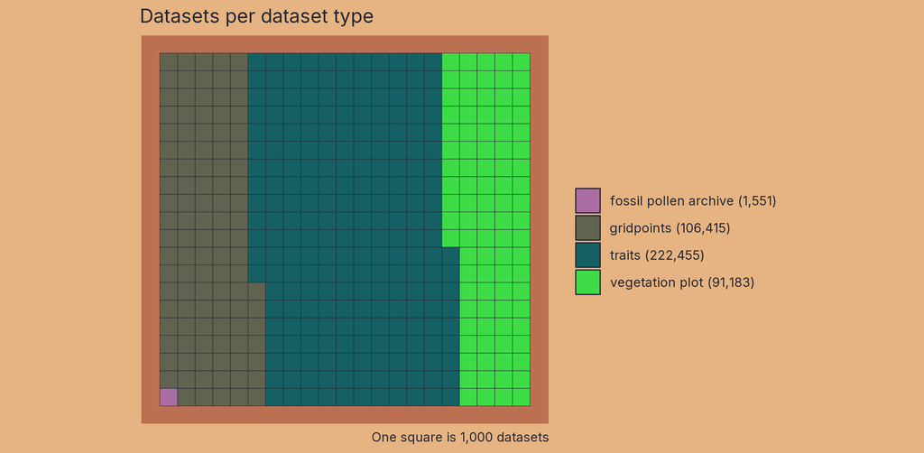

#### Dataset Source-Types (`DatasetSourceTypeID`)

VegVault maintains detailed information about the primary data source, thereby enhancing the findability and referencing of primary data sources. Each Dataset is derived from a specific Source-Type that provides detailed information on the source used to retrieve the original data. The current Source-Types in VegVault include:

- BIEN - [Botanical Information and Ecology Network](https://bien.nceas.ucsb.edu/bien/)
- sPlotOpen - [The open-access version of sPlot](https://idiv-biodiversity.de/en/splot/splotopen.html)
- TRY - [TRY Plant Trait Database](https://www.try-db.org/TryWeb/Home.php)
- Neotoma-FOSSILPOL (source type `FOSSILPOL` in the database) - [The workflow that aims to process and standardise global palaeoecological pollen data](https://hope-uib-bio.github.io/FOSSILPOL-website/). Note that we specifically state Neotoma-FOSSILPOL and not just Neotoma, as FOSSILPOL not only provides the data acquisition but also alters it (e.g., creating new age-depth models). It also addresses major challenges in paleoecological data integration, such as age uncertainty, by incorporating probabilistic age-depth models and their associated uncertainty matrices. This enables the propagation of temporal uncertainty in subsequent analyses, a critical advancement for robust macroecological studies, previously flagged as a major issue with paleo-data.
- gridpoints - artificially created Datasets to hold abiotic data. See Database Assembly for more details.

| column_name | data_type | description |
| --- | --- | --- |
| data_source_type_id | INTEGER | ID of a Dataset Source-Type (unique) |
| dataset_source_type | TEXT | Text description of individual Dataset Source-Type (currently, BIEN, sPlotOpen, TRY, FOSSILPOL, gridpoints) |

Column names and types for table `DatasetSourceTypeID`.

| column_name | data_type | description |
| --- | --- | --- |
| data_source_type_id | INTEGER | ID of a Dataset Source-Type |
| reference_id | INTEGER | ID of a Reference |

Column names and types for table `DatasetSourceTypeReference`.

[figure not shown]

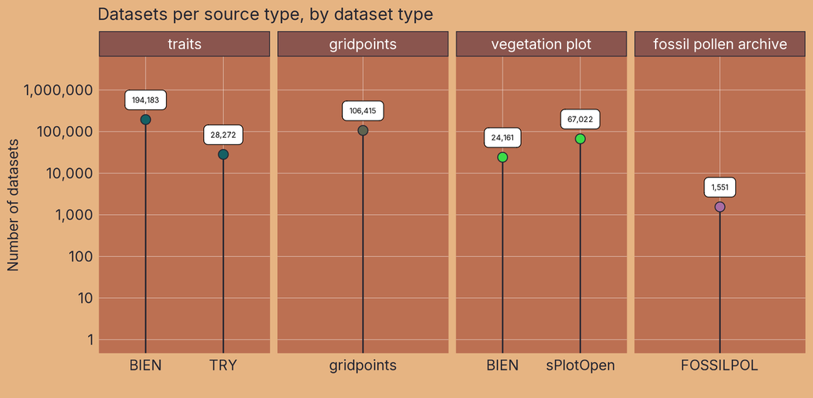

#### Dataset Sources (`DatasetSourcesID`)

Each individual Dataset from a specific Dataset Source-Type can have information on the source of the data (i.e. sub-database). VegVault 2.0.0 currently includes 693 sources of Datasets, where each dataset can also have one or more direct references to specific data, ensuring that users can accurately cite and verify the sources of their data. This should help to promote better findability of the primary source of data and referencing.

| column_name | data_type | description |
| --- | --- | --- |
| data_source_id | INTEGER | ID of a Dataset Source (unique) |
| data_source_desc | TEXT | Text description of individual Dataset Sources (e.g., name of the sub-database from the primary source) |

Column names and types for table `DatasetSourcesID`.

| column_name | data_type | description |
| --- | --- | --- |
| data_source_id | INTEGER | ID of a Dataset Source |
| reference_id | INTEGER | ID of a Reference |

Column names and types for table `DatasetSourcesReference`.

[figure not shown]

Currently, there are 693 sources of Datasets.

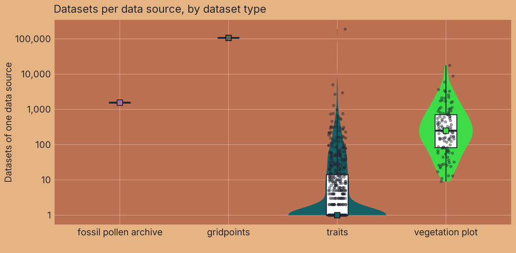

#### Sampling Methods (`SamplingMethodID`)

Sampling methods vary significantly across the different types of Datasets integrated into VegVault, reflecting the diverse nature of the data collected. Such information is crucial for understanding the context and limitations of each Dataset Type. For contemporary vegetation plots, sampling involves standardised plot inventories and surveys that capture detailed vegetation characteristics across various regions. Fossil pollen data are collected from sediment records from numerous different depositional environments representing past vegetation. Therefore, information on sampling methods is only available for both `vegetation_plot` and `fossil_pollen_archive` Datasets, providing metadata that ensures accurate and contextually relevant analyses.

| column_name | data_type | description |
| --- | --- | --- |
| sampling_method_id | INTEGER | ID of a Dataset Sampling Method (unique) |
| sampling_method_details | TEXT | Text description of individual Dataset Sampling Methods |

Column names and types for table `SamplingMethodID`.

| column_name | data_type | description |
| --- | --- | --- |
| sampling_method_id | INTEGER | ID of a Dataset Sampling Method |
| reference_id | INTEGER | ID of a Reference |

Column names and types for table `SamplingMethodReference`.

[figure not shown]

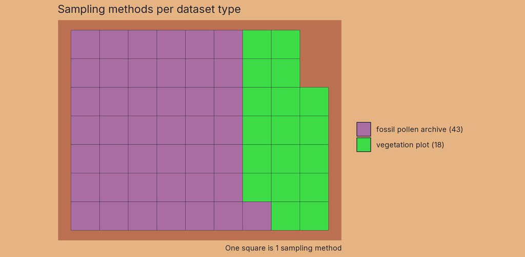

#### Dataset References (`DatasetReferences`)

To support robust and transparent scientific research, each Dataset in VegVault can have multiple references at different levels. The Dataset Source-Type, Dataset Source, and Sampling Method can all have their own references, providing detailed provenance and citation information. This multi-level referencing system enhances the traceability and validation of the data. Each Dataset can also have one or more direct references to specific data, further ensuring that users can accurately cite and verify the sources of their data.

| column_name | data_type | description |
| --- | --- | --- |
| dataset_id | INTEGER | ID of a Dataset |
| reference_id | INTEGER | ID of a Reference |

Column names and types for table `DatasetReferences`.

[figure not shown]

This means that one dataset can have one/several references from each of those parts. Let’s take a look at an example of what that could mean in practice.

We have selected the dataset fossilpol_1001 (dataset ID 91184 in this version), Hail Lake in Yukon, which is a fossil pollen archive. Therefore, it has the reference of the *Dataset Source-Type*:

- *Flantua, S. G. A., Mottl, O., Felde, V. A., Bhatta, K. P., Birks, H. H., Grytnes, J.-A., Seddon, A. W. R., & Birks, H. J. B. (2023). A guide to the processing and standardization of global palaeoecological data for large-scale syntheses using fossil pollen. Global Ecology and Biogeography, 32, 1377–1394. https://doi.org/10.1111/geb.13693*

and reference for the individual dataset:

- *Grimm, E.C., 2008. Neotoma: an ecosystem database for the Pliocene, Pleistocene, and Holocene. Illinois State Museum Scientific Papers E Series, 1.*

## Samples

Samples represent the main unit of data in VegVault, serving as the fundamental building blocks for all analyses. There are currently 12,459,714 Samples in VegVault 2.0.0 (of which 1,569,221 are gridpoints of abiotic data, see Database Assembly).

VegVault encompasses both contemporary and paleo data, necessitating accurate age information for each Sample. Contemporary Samples are assigned an age of `0`, while Samples from fossil pollen records are in calibrated years before the present (cal yr BP). The *present* is here specified as `1950 AD`.

### Sample Structure Overview (`Samples`)

The table contains one Sample per row, with each Sample containing: a unique Sample ID (`sample_id`), Sample name (`sample_name`), temporal information about Sample (age), sample site (size of the plot if available; `sample_size_id`), and additional information about sample (`sample_details`; this is currently not being used). As VegVault encompasses both contemporary and paleo-data, accurate age information is required for each Sample.

| column_name | data_type | description |
| --- | --- | --- |
| sample_id | INTEGER | ID of a Sample (unique) |
| sample_name | TEXT | Name of a Sample |
| sample_details | TEXT | Specific description of a Sample. Currently not being used. |
| age | REAL | Age of sample. Mainly used for `fossil_pollen_archives`, where note the age of a Sample in calibrated years before present. Note that all contemporary Samples, have age of 0. |
| sample_size_id | INTEGER | ID of a Sample Size |

Column names and types for table `Samples`.

[figure not shown]

### Dataset-Sample (`DatasetSample`)

Each Sample is linked to a specific Dataset via the `DatasetSample` table, which ensures that every Sample is correctly associated with its corresponding Dataset Type (whether it is `vegetation_plot`, `fossil_pollen_archive`, `traits`, or `gridpoint`) and other Dataset properties (e.g., geographic location). One Dataset contains several Samples only in a case where they differ in time (`age`).

| column_name | data_type | description |
| --- | --- | --- |
| dataset_id | INTEGER | ID of a Dataset |
| sample_id | INTEGER | ID of a Sample |

Column names and types for table `DatasetSample`.

[figure not shown]

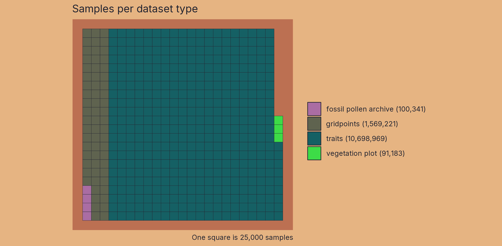

### Sample Size (`SampleSizeID`)

The size of vegetation plots can vary substantially. This detail is crucial for ecological studies where plot size can influence species diversity and abundance metrics, thus impacting follow-up analyses and interpretations. To account for this variability, information about the plot size is recorded separately for each contemporary Sample.

| column_name | data_type | description |
| --- | --- | --- |
| sample_size_id | INTEGER | ID of a size category (unique) |
| sample_size | REAL | Numeric expression of size |
| description | TEXT | Mostly description of units in which the values are stored |

Column names and types for table `SampleSizeID`.

[figure not shown]

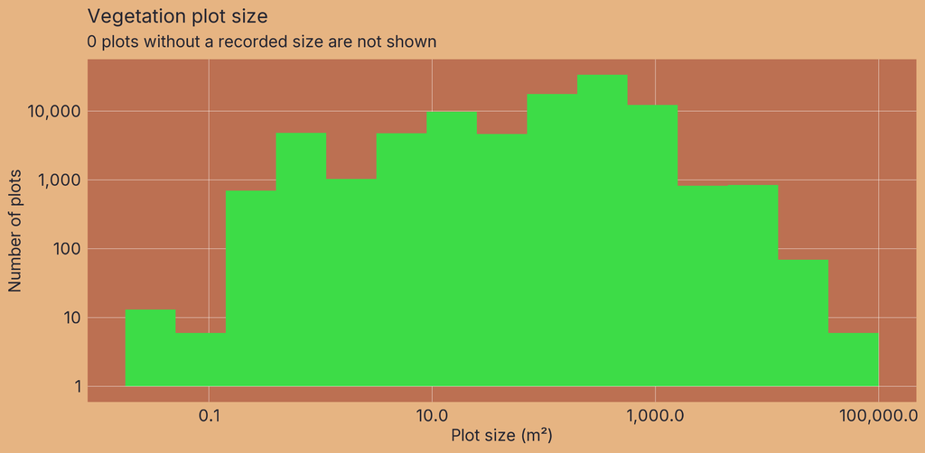

### Sample age uncertainty (`SampleUncertainty`)

Each Sample from the `fossil_pollen_archive` Dataset is also associated with an uncertainty matrix generated during the re-estimation of ages using [FOSSILPOL workflow](https://bit.ly/FOSSILPOL). This matrix provides a range of potential ages derived from age-depth modelling, reflecting the inherent uncertainty in dating paleoecological records.

| column_name | data_type | description |
| --- | --- | --- |
| sample_id | INTEGER | ID of a Sample |
| iteration | INTEGER | ID of a iteration from age depth model. Currently, the is 1000 iteration per each Sample. |
| age | INTEGER | Potential age of a Sample |

Column names and types for table `SampleUncertainty`.

[figure not shown]

We can show this on the previously selected fossil pollen archive fossilpol_1001 (Hail Lake, dataset ID 91184 in this version).

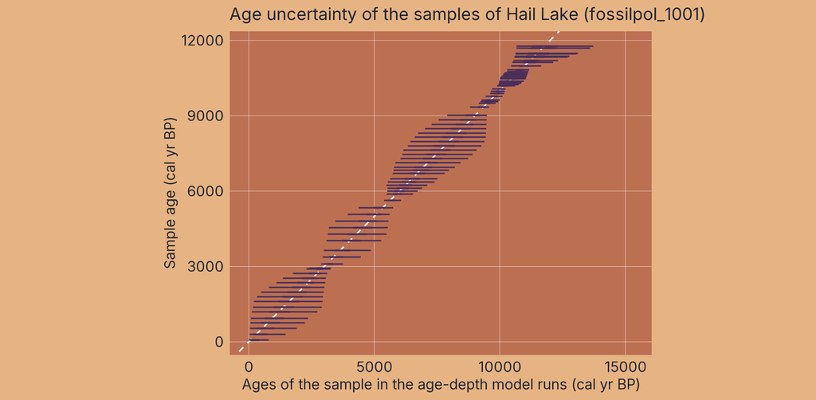

### Sample Reference

Each Sample in VegVault can have specific References in addition to those at the Dataset-level. These individual Sample References provide detailed provenance and citation information, ensuring that users can trace the origin and validation of each data point. Note that a single Sample can have several References. This level of referencing enhances the transparency and reliability of the data, especially when the dataset continues to be updated in the future.

| column_name | data_type | description |
| --- | --- | --- |
| sample_id | INTEGER | ID of a Sample |
| reference_id | INTEGER | ID of a Reference |

Column names and types for table `SampleReference`.

[figure not shown]

## Taxa

### Taxa Structure Overview (`Taxa`)

The VegVault database records the original taxonomic names derived directly from the primary data sources, and currently, it holds 109,220 taxonomic names.

| column_name | data_type | description |
| --- | --- | --- |
| taxon_id | INTEGER | ID of a Taxon (unique) |
| taxon_name | TEXT | Name of a Taxon from primary source. |

Column names and types for table `Taxa`.

[figure not shown]

### Sample-Taxa (`SampleTaxa`)

Each individual Taxon is linked to corresponding Samples through the `SampleTaxa` table, ensuring accurate and systematic association between species and their ecological data. Note that the abundance information varies across the primary data sources. Therefore, users have to be careful while processing data from various sources.

| column_name | data_type | description |
| --- | --- | --- |
| sample_id | INTEGER | ID of a Sample |
| taxon_id | INTEGER | ID of a Taxon |
| value | REAL | Abundance representation of a Taxon (the units may differ among primary sources, i.e. Dataset Source-Types) |

Column names and types for table SampleTaxa.

[figure not shown]

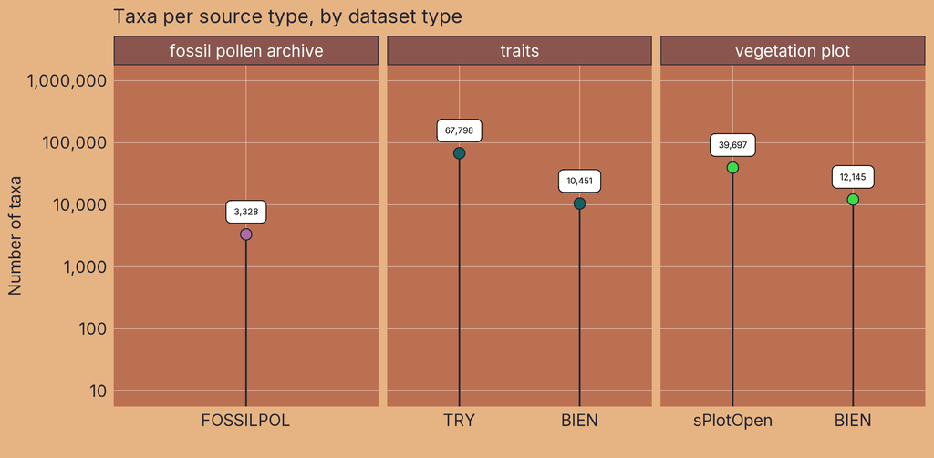

### Taxon Classification (`TaxonClassification`)

Each taxonomic name undergoes an automated classification (see Database Assembly) and results are stored in the `TaxonClassification` table. To classify the diverse taxa present in the VegVault database, the {taxospace} R package was used. This tool automatically aligns taxa names with the [Taxonomy Backbone](https://www.gbif.org/dataset/d7dddbf4-2cf0-4f39-9b2a-bb099caae36c) from the [Global Biodiversity Information Facility](https://www.gbif.org/), providing a standardized classification framework. Specifically, we try to find the best match of the raw names of taxa using the [Global Names Verifier](https://verifier.globalnames.org/). Two kinds of names are corrected by hand after the automatic classification: fossil pollen types that combine two or more taxa, and the pollen type “Pinus Picea” (see Database Assembly).

| column_name | data_type | description |
| --- | --- | --- |
| taxon_id | INTEGER | ID of a Taxon |
| taxon_species | INTEGER | ID of a Taxon, which was assign as species level |
| taxon_genus | INTEGER | ID of a Taxon, which was assign as genus level |
| taxon_family | INTEGER | ID of a Taxon, which was assign as family level |

Column names and types for table `TaxonClassification`.

[figure not shown]

Taxonomic classification for some Taxa might be only available down to the genus or family level, while most of the data is classified to species level. Classification information, detailed up to the family level, is stored for each taxon, ensuring consistency and facilitating comparative analyses across different datasets. Currently, the VegVault database holds 109,220 taxonomic names, of which we were unable to classify only 900 (0.8%).

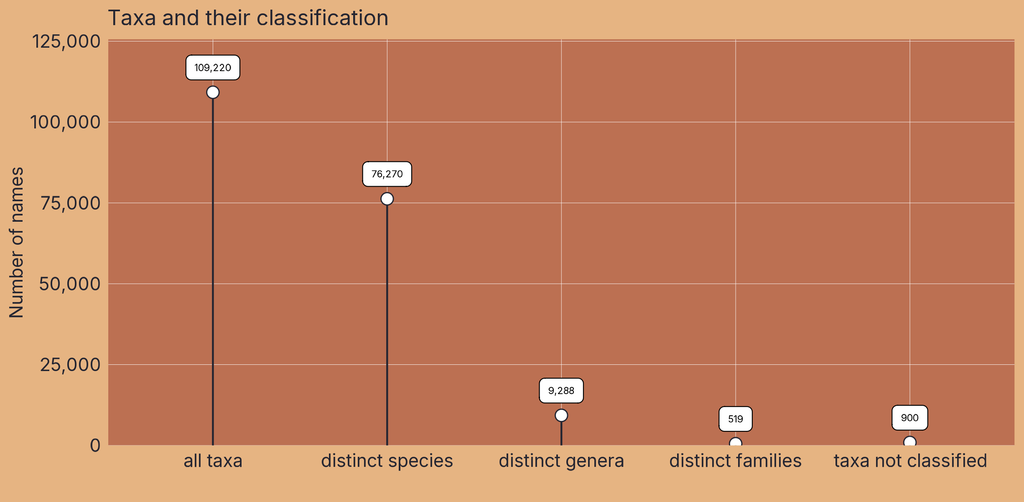

### Taxon Reference (`TaxonReference`)

Each taxon might get a reference. Currently, this is used to track the origin of the Taxon name (i.e. which primary source was used first with this Taxon). Note that Taxa, generated from taxonomic classification are associated with `taxospace` reference.

| column_name | data_type | description |
| --- | --- | --- |
| taxon_id | INTEGER | ID of a Taxon |
| reference_id | INTEGER | ID of a Reference |

Column names and types for table `TaxonReference`.

## Traits

### Traits Structure Overview (`Traits`)

The Traits table contains the list of functional traits currently contained in VegVault. The table contains one Trait per row, with each Trait containing: a unique Trait ID (`trait_id`), original Trait name from primary source (`trait_name`), and Trait Domain (`trait_domain_id`). Functional traits of vegetation taxa follow the same structure of Dataset and Samples obtained directly from Dataset Source-Types.

| column_name | data_type | description |
| --- | --- | --- |
| trait_id | INTEGER | ID of a Trait (unique) |
| trait_domain_id | INTEGER | ID of a Trait Domain |
| trait_name | TEXT | Name of the trait from the primary source. See ‘VegVault Content’ for the details about the specific columns used from primary sources. |

Column names and types for table `Traits`.

[figure not shown]

### Traits Domain (`TraitsDomain`)

Traits are grouped into Trait Domains to allow for easier aggregation of Traits across data sources. As there are differences in trait names across sources of data and individual Datasets, the VegVault database contains Trait Domain information to group traits together. In total, 6 Trait Domains are present: `Diaspore mass`, `Leaf Area`, `Leaf mass per area`, `Leaf nitrogen content per unit mass`, `Plant heigh`, and `Stem specific density`, following [Diaz et al. (2016)](https://www.nature.com/articles/nature16489). The names are stored as in VegVault 1.0.0, including the spelling `Plant heigh` for plant height. Yet, it is up to the user to decide how to further aggregate trait values if multiple trait Samples of one Trait Domain are available for the same environmental or taxonomic entity.

| column_name | data_type | description |
| --- | --- | --- |
| trait_domain_id | INTEGER | ID of a Trait Domain (unique) |
| trait_domain_name | TEXT | Name of the Trait Domain from Diaz et al. (2016) |
| trait_unit | TEXT | Canonical unit used by all values in the Trait Domain |
| trait_domanin_description | TEXT | NA |
| trait_domain_description | NA | Additional information about the Trait Domain |

Column names and types for table `TraitsDomain`.

[figure not shown]

| Trait domain | Trait | Data Source |
| --- | --- | --- |
| Diaspore mass | seed mass | BIEN |
| Diaspore mass | Seed dry mass | TRY |
| Leaf Area | leaf area | BIEN |
| Leaf Area | Leaf area (in case of compound leaves undefined if leaf or leaflet, undefined if petiole is in- or exluded) | TRY |
| Leaf Area | Leaf area (in case of compound leaves: leaf, petiole excluded) | TRY |
| Leaf Area | Leaf area (in case of compound leaves: leaf, petiole included) | TRY |
| Leaf Area | Leaf area (in case of compound leaves: leaf, undefined if petiole in- or excluded) | TRY |
| Leaf mass per area | leaf mass per area | BIEN |
| Leaf mass per area | Leaf area per leaf dry mass (specific leaf area, SLA or 1/LMA): petiole included | TRY |
| Leaf mass per area | Leaf area per leaf dry mass (specific leaf area, SLA or 1/LMA): undefined if petiole is in- or excluded) | TRY |
| Leaf nitrogen content per unit mass | leaf nitrogen content per leaf dry mass | BIEN |
| Leaf nitrogen content per unit mass | Leaf nitrogen (N) content per leaf dry mass | TRY |
| Plant heigh | whole plant height | BIEN |
| Plant heigh | Plant height vegetative | TRY |
| Stem specific density | stem wood density | BIEN |
| Stem specific density | Stem specific density (SSD, stem dry mass per stem fresh volume) or wood density | TRY |

Overview of Trait Domains and their associated Traits

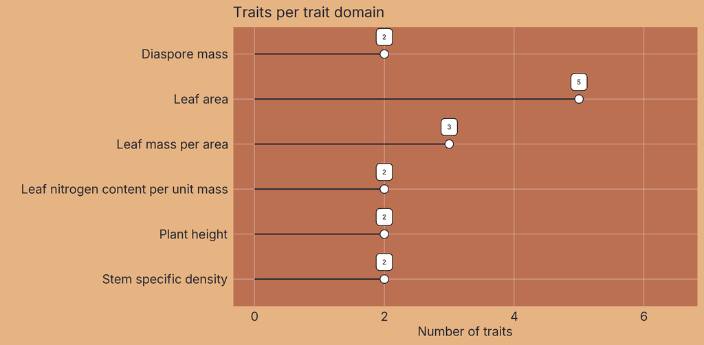

### Traits value (`TraitsValue`)

In general, data of functional traits of vegetation taxa follow the same structure of the Dataset and Samples obtained directly from the Dataset Source-Types. Therefore, `TraitsValue` table contains not only the actual measured value of Trait observation but also information about linking information across Datasets, Samples, and Taxa. This comprehensive linkage ensures that each Trait value is accurately associated with its relevant ecological, environmental and taxonomic context.

Since VegVault 2.0.0, every trait value is stored in the unit of its Trait Domain (`trait_unit` of `TraitsDomain`), shown in the table below. Each value references exactly one versioned conversion rule of `TraitUnitConversion` and, when it is derived from another trait, one derivation rule of `TraitDerivation`, such as the reciprocal that turns specific leaf area (SLA) into leaf mass per area (LMA). The values and units as the data providers reported them are not stored in the database; they are part of the trait data release ([VegVault-Trait_data](https://doi.org/10.5281/zenodo.24505585)), together with the audit tables of the conversion.

| Trait Domain | Unit |
| --- | --- |
| Diaspore mass | mg |
| Leaf Area | mm2 |
| Leaf mass per area | mg/mm2 |
| Leaf nitrogen content per unit mass | mg/g |
| Plant heigh | m |
| Stem specific density | g/cm3 |

Unit of the values of each Trait Domain.

| column_name | data_type | description |
| --- | --- | --- |
| trait_id | INTEGER | ID of a Trait |
| dataset_id | INTEGER | ID of a Dataset |
| sample_id | INTEGER | ID of a Sample |
| taxon_id | INTEGER | ID of a Taxon |
| trait_value | REAL | Value of specific measured observation of Trait. |
| trait_unit_conversion_id | INTEGER | ID of the required unit conversion rule |
| trait_derivation_id | INTEGER | ID of an optional derived-trait rule |

Column names and types for table `TraitsValue`.

[figure not shown]

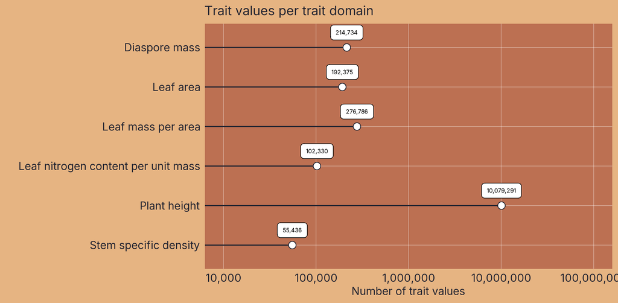

### Trait Unit Conversion (`TraitUnitConversion`)

The `TraitUnitConversion` table holds the rules that bring the value of each data provider to the unit of its Trait Domain, one rule per row. A rule applies to one trait of one provider, and sometimes only to one dataset of that provider, and it is kept under a unique name and a version, so that every stored value can be traced to the rule that converted it.

| column_name | data_type | description |
| --- | --- | --- |
| trait_unit_conversion_id | INTEGER | ID of a conversion rule (unique) |
| conversion_rule_key | TEXT | Name of the rule (unique), for example `try_leaf_area_3112_cm2` |
| rule_version | TEXT | Version of the rule |
| source_provider | TEXT | Data provider the rule applies to (`TRY` or `BIEN`) |
| source_trait_id | TEXT | Trait of the data provider the rule applies to |
| source_dataset_key | TEXT | Dataset of the data provider the rule is limited to (empty for all datasets) |
| normalized_original_unit | TEXT | Unit as the data provider reported it, written in one standard way |
| standardized_unit | TEXT | Unit after the conversion, the unit of the Trait Domain |
| trait_dimension | TEXT | Physical dimension of the trait, for example `length` or `area` |
| operation | TEXT | Kind of conversion: `identity`, `multiply` or `reciprocal` |
| multiplier | REAL | Factor of the conversion |
| evidence | TEXT | Reason or source of the rule |

Column names and types for table `TraitUnitConversion`.

### Trait Derivation (`TraitDerivation`)

The `TraitDerivation` table holds the rules that compute one trait from another after its unit conversion, such as leaf mass per area from specific leaf area.

| column_name | data_type | description |
| --- | --- | --- |
| trait_derivation_id | INTEGER | ID of a derivation rule (unique) |
| derivation_rule_key | TEXT | Name of the rule (unique), for example `sla_to_lma` |
| rule_version | TEXT | Version of the rule |
| input_unit | TEXT | Unit of the trait the rule starts from |
| output_unit | TEXT | Unit of the derived trait |
| trait_dimension | TEXT | Physical dimension of the derived trait |
| operation | TEXT | Kind of derivation, for example `reciprocal` |
| multiplier | REAL | Factor of the derivation |
| evidence | TEXT | Reason or source of the rule |

Column names and types for table `TraitDerivation`.

[figure not shown]

### Traits Reference (`TraitsReference`)

To ensure clarity and reproducibility, each Trait in VegVault can have additional References beyond the general Dataset and Sample References. These Trait-specific References provide detailed provenance and citation information, supporting rigorous scientific research and enabling users to trace the origins and validation of each trait value.

| column_name | data_type | description |
| --- | --- | --- |
| trait_id | INTEGER | ID of a Trait |
| reference_id | INTEGER | ID of a Reference |

Column names and types for table `TraitsReference`.

[figure not shown]

## Abiotic Variables

The abiotic data in the VegVault database provide essential information on environmental factors affecting vegetation distribution and traits. Currently, VegVault includes abiotic data from [CHELSA](https://chelsa-climate.org/), [CHELSA-TRACE21](https://doi.org/10.16904/envidat.211), and the [Harmonized World Soil Database (HWSD) v2.2](https://data.apps.fao.org/catalog/iso/ff5c613c-75bb-46a9-a162-bc728059b465). CHELSA and CHELSA-TRACE21 provide high-resolution climate data, while HWSD offers detailed soil information. VegVault 1.0.0 named the soil source WoSIS; it was HWSD v2.0 or v2.01 (the exact version was not recorded).

### Abiotic variables (`AbioticVariable`)

As VegVault contains abiotic variables from several primary sources, the `AbioticVariable` table contains descriptions of abiotic variables (`abiotic_variable_name`), their units (`abiotic_variable_unit`), and measurement details (`measure_details`). These data include variables such as climate and soil conditions, which are crucial for understanding the ecological contexts of vegetation dynamics.

| column_name | data_type | description |
| --- | --- | --- |
| abiotic_variable_id | INTEGER | ID of a Abiotic Variable |
| abiotic_variable_name | TEXT | Name of a Abiotic Variable from primary source |
| abiotic_variable_unit | TEXT | Unit of a Abiotic Variable |
| measure_details | TEXT | Additional details about Abiotic Variable |

Column names and types for table `AbioticVariable`.

[figure not shown]

| Variable name | Variable unit | Source of data |
| --- | --- | --- |
| bio1 | C (degree Celsius) | mean annual air temperature |
| bio4 | C/100 (hundredths of a degree Celsius) | temperature seasonality: standard deviation of the monthly mean temperatures times 100 |
| bio6 | C (degree Celsius) | mean daily minimum air temperature of the coldest month |
| bio12 | kg m-2 year-1 | annual precipitation amount |
| bio15 | Unitless | precipitation seasonality |
| bio18 | kg m-2 quarter-1 | precipitation amount of the warmest quarter |
| bio19 | kg m-2 quarter-1 | precipitation amount of the coldest quarter |
| HWSD2 | Unitless | HWSD-soil_group |

Table showing abiotic variables.

Some properties of the values need attention:

- `bio4` (temperature seasonality) is in hundredths of a degree Celsius, as its unit says; in VegVault 1.0.0, the present-day `bio4` was 0 south of about 65.7° N because of a truncated download.
- A present-day `bio12` (annual precipitation) of 6553.5 kg m<sup>-2</sup> is the storage limit of CHELSA V2.1, so it is a lower bound.
- CHELSA-TRACE21 stores precipitation in whole kg m<sup>-2</sup>, so a dry quarter with less than 0.5 kg m<sup>-2</sup> is 0 in the past (`bio18`, `bio19`), while the present-day values come in steps of 0.1.
- In the Sahel and the Sudanian belt, the coldest quarter of `bio19` can be the dry winter in one product and the rainy season in the other, so `bio19` can change between 0 and several hundred kg m<sup>-2</sup> between the present day and the past.

### Abiotic Data (`AbioticData`)

The `AbioticData` table holds the actual values of abiotic variables (the units are the same for each `AbioticVariable`).

| column_name | data_type | description |
| --- | --- | --- |
| sample_id | INTEGER | ID of a Sample |
| abiotic_variable_id | INTEGER | ID of an Abiotic Variable |
| abiotic_value | REAL | Value of an Abiotic Variable |

Column names and types for table `AbioticData`.

[figure not shown]

### Gridpoints (`AbioticDataReference`)

Gridpoints are stored in artificially created Datasets and Samples, with one Dataset holding more Samples only if they differ in age. We have estimated the spatial and temporal distance between each gridpoint and other non-gridpoint Samples (`vegetation_plot`, `fossil_pollen_archive`, and `traits`). We store the link between gridpoint and non-gridpoint Samples as well as the spatial and temporal distance. A link is kept when the two are at most 50 km and at most 5,000 years apart, and any gridpoint Sample without a link is discarded as not relevant for the vegetation dynamics.

Since VegVault 2.0.0, the links are stored once per position, a distinct combination of longitude, latitude and age, because many Samples share a position. `AbioticDataReference` is a view, a stored query: it combines the tables `SamplePosition` (the position of each non-gridpoint Sample) and `PositionLink` (the gridpoints linked to each position) and returns one row per Sample and linked gridpoint, with the same columns as the table `AbioticDataReference` of VegVault 1.0.0. The positions themselves are in the table `Positions`.

| column_name | data_type | description |
| --- | --- | --- |
| sample_id | INTEGER | ID of non-gridpoint Sample |
| sample_ref_id | INTEGER | ID of gridpoint Sample |
| distance_in_km | INTEGER | Distance among samples expressed in kilometres |
| distance_in_years | INTEGER | Distance among samples expressed in years |

Column names and types for view `AbioticDataReference`.

[figure not shown]

| column_name | data_type | description |
| --- | --- | --- |
| position_id | INTEGER | ID of a position (unique) |
| coord_long | REAL | Longitude of the position |
| coord_lat | REAL | Latitude of the position |
| age | REAL | Age of the position (cal yr BP) |

Column names and types for table `Positions`.

| column_name | data_type | description |
| --- | --- | --- |
| sample_id | INTEGER | ID of a non-gridpoint Sample |
| position_id | INTEGER | ID of the position of the Sample |

Column names and types for table `SamplePosition`.

| column_name | data_type | description |
| --- | --- | --- |
| position_id | INTEGER | ID of a position |
| sample_ref_id | INTEGER | ID of a gridpoint Sample linked to the position |
| distance_in_km | INTEGER | Distance between the position and the gridpoint in whole kilometres |
| distance_in_years | INTEGER | Age difference between the position and the gridpoint in whole years |

Column names and types for table `PositionLink`.

Such data structure allows that environmental context is readily available for each vegetation and trait Sample. For each non-gridpoint Sample, users can select the closest spatio-temporally abiotic data or get average from all surrounding gridpoints.

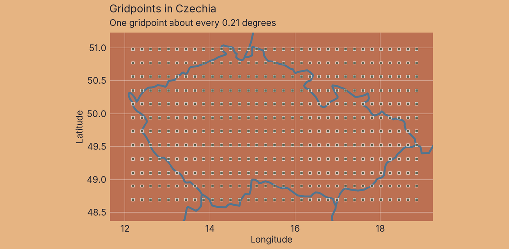

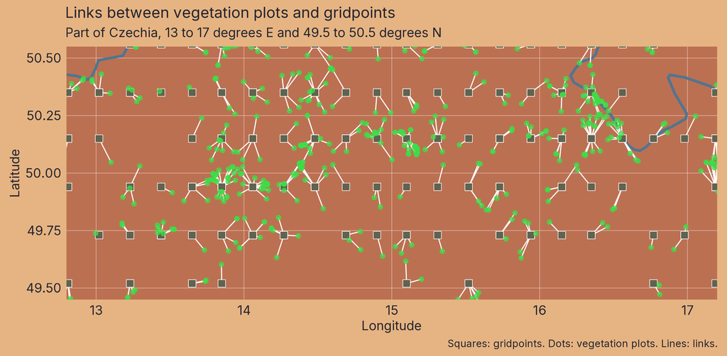

### Abiotic Variable Reference (`AbioticVariableReference`)

Each Abiotic Variable can have a separate Reference, in addition to a Dataset and Sample.

| column_name | data_type | description |
| --- | --- | --- |
| abiotic_variable_id | INTEGER | ID of an Abiotic Variable |
| reference_id | INTEGER | ID of a Reference |

Column names and types for table `AbioticVariableReference`.

## References

The `References` table is a central component that serves all sections of the VegVault database. This table contains all References, independent of the source of the reference and the type of data. Each row contains a single Reference, which is then linked to the type of data which is being referenced. This allows a single Reference to be used across data types, but also one data point having many different references.

Moreover, most primary sources of the data have a license, which requires correct attribution. Therefore, each Reference has information if such a Reference needs to be cited while using the specific data.

Back to top